# Capital One Campus Data Challenge

Naveen Sampath

The data is collected by New York City Taxi and Limousine commission (popularly known as TLC) about **Green Taxis**. The data used for this challenge is the trips made for September 2015. This dataset can be directly downloaded from the site http://www.nyc.gov/html/tlc/html/about/trip_record_data.shtml

## Function to load the necessary libraries

```r
load_package <- function(packages){
  new_package <- packages[!(packages %in% installed.packages()[, "Package"])]
  if (length(new_package))
    install.packages(new_package, dependencies = TRUE)
  sapply(packages, require, character.only = TRUE)
}

packages <- c("ggplot2", "lars","knitr", "dplyr", "randomForest","gplots", "corrplot","caret","RCurl","data.table", "rattle","rmarkdown", "lubridate", "ggmap", "tidyverse", "GGally", "olsrr")

load_package(packages) # Calling the load_package function
```

## Question 1

### 1. Programmatically download and load into your favorite analytical tool the trip data for September 2015.

The url for the dataset for September 2015 can be retrieved from the “view page source”.

```r
url = "https://s3.amazonaws.com/nyc-tlc/trip+data/green_tripdata_2015-09.csv"
file_name = "green_tripdata_2015-09.csv"

# Condition to check whether the dataset is present in the local disk
if(!file.exists(file_name)) {
    download.file(url, destfile=file_name, method="curl")
}

# Loading the data
green_taxi <- read.csv("green_tripdata_2015-09.csv", header = TRUE, stringsAsFactors = FALSE)

head(green_taxi) # get top 5 rows for overview
```

```
##   VendorID lpep_pickup_datetime Lpep_dropoff_datetime Store_and_fwd_flag
## 1        2  2015-09-01 00:02:34   2015-09-01 00:02:38                  N
## 2        2  2015-09-01 00:04:20   2015-09-01 00:04:24                  N
## 3        2  2015-09-01 00:01:50   2015-09-01 00:04:24                  N
## 4        2  2015-09-01 00:02:36   2015-09-01 00:06:42                  N
## 5        2  2015-09-01 00:00:14   2015-09-01 00:04:20                  N
## 6        2  2015-09-01 00:00:39   2015-09-01 00:05:20                  N
##   RateCodeID Pickup_longitude Pickup_latitude Dropoff_longitude
## 1          5        -73.97948        40.68496         -73.97943
## 2          5        -74.01080        40.91222         -74.01078
## 3          1        -73.92141        40.76671         -73.91441
## 4          1        -73.92139        40.76668         -73.93143
## 5          1        -73.95548        40.71405         -73.94441
## 6          1        -73.94530        40.80819         -73.93767
##   Dropoff_latitude Passenger_count Trip_distance Fare_amount Extra MTA_tax
```

[output cut: 20 more lines]

```r
summary(green_taxi) # to get the general idea of the data
```

```
##     VendorID     lpep_pickup_datetime Lpep_dropoff_datetime
##  Min.   :1.000   Length:1494926       Length:1494926
##  1st Qu.:2.000   Class :character     Class :character
##  Median :2.000   Mode  :character     Mode  :character
##  Mean   :1.782
##  3rd Qu.:2.000
##  Max.   :2.000
##
##  Store_and_fwd_flag   RateCodeID     Pickup_longitude Pickup_latitude
##  Length:1494926     Min.   : 1.000   Min.   :-83.32   Min.   : 0.00
##  Class :character   1st Qu.: 1.000   1st Qu.:-73.96   1st Qu.:40.70
##  Mode  :character   Median : 1.000   Median :-73.95   Median :40.75
##                     Mean   : 1.098   Mean   :-73.83   Mean   :40.69
##                     3rd Qu.: 1.000   3rd Qu.:-73.92   3rd Qu.:40.80
##                     Max.   :99.000   Max.   :  0.00   Max.   :43.18
##
##  Dropoff_longitude Dropoff_latitude Passenger_count Trip_distance
##  Min.   :-83.43    Min.   : 0.00    Min.   :0.000   Min.   :  0.000
##  1st Qu.:-73.97    1st Qu.:40.70    1st Qu.:1.000   1st Qu.:  1.100
##  Median :-73.95    Median :40.75    Median :1.000   Median :  1.980
##  Mean   :-73.84    Mean   :40.69    Mean   :1.371   Mean   :  2.968
##  3rd Qu.:-73.91    3rd Qu.:40.79    3rd Qu.:1.000   3rd Qu.:  3.740
##  Max.   :  0.00    Max.   :42.80    Max.   :9.000   Max.   :603.100
##
##   Fare_amount          Extra            MTA_tax          Tip_amount
##  Min.   :-475.00   Min.   :-1.0000   Min.   :-0.5000   Min.   :-50.000
##  1st Qu.:   6.50   1st Qu.: 0.0000   1st Qu.: 0.5000   1st Qu.:  0.000
##  Median :   9.50   Median : 0.5000   Median : 0.5000   Median :  0.000
##  Mean   :  12.54   Mean   : 0.3513   Mean   : 0.4866   Mean   :  1.236
##  3rd Qu.:  15.50   3rd Qu.: 0.5000   3rd Qu.: 0.5000   3rd Qu.:  2.000
##  Max.   : 580.50   Max.   :12.0000   Max.   : 0.5000   Max.   :300.000
##
##   Tolls_amount      Ehail_fee      improvement_surcharge  Total_amount
##  Min.   :-15.2900   Mode:logical   Min.   :-0.3000       Min.   :-475.00
##  1st Qu.:  0.0000   NA's:1494926   1st Qu.: 0.3000       1st Qu.:   8.16
##  Median :  0.0000                  Median : 0.3000       Median :  11.76
##  Mean   :  0.1231                  Mean   : 0.2921       Mean   :  15.03
##  3rd Qu.:  0.0000                  3rd Qu.: 0.3000       3rd Qu.:  18.30
##  Max.   : 95.7500                  Max.   : 0.3000       Max.   : 581.30
##
##   Payment_type     Trip_type
##  Min.   :1.000   Min.   :1.000
##  1st Qu.:1.000   1st Qu.:1.000
##  Median :2.000   Median :1.000
##  Mean   :1.541   Mean   :1.022
##  3rd Qu.:2.000   3rd Qu.:1.000
##  Max.   :5.000   Max.   :2.000
##                  NA's   :4
```

### 2. Report how many rows and columns of data you have loaded.

```r
dim(green_taxi) # to get the number of rows and columns of the dataset
```

```
## [1] 1494926      21
```

```r
paste0("Number of rows: ", nrow(green_taxi))
```

```
## [1] "Number of rows: 1494926"
```

```r
paste0("Number of columns: ", ncol(green_taxi))
```

```
## [1] "Number of columns: 21"
```

NYC Dataset contains 1494926 rows and 21 columns. Each row signifies one trip and the detailed information about the trip is recorded with 21 columns which includes Pickup/Dropoff location, Trip distance, Charge for the cab along with tip and toll amount and with some extra information.

## Question 2

### 1. Plot a histogram of the number of the trip distance (“Trip Distance”).

Histogram is a plot which is used to visualize the frequency distribution of the continous data. Histograms are considered to be a good summary for the distribution of values in a large dataset.

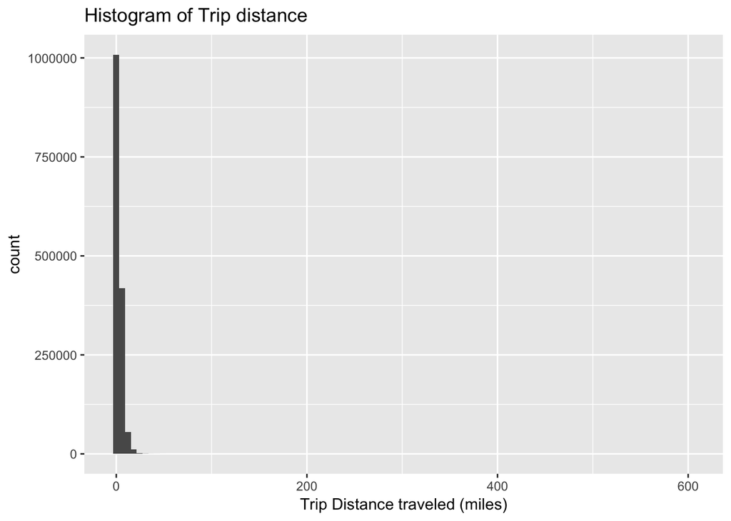

```r
ggplot(data=green_taxi, aes(green_taxi$Trip_distance)) + geom_histogram(bins = 100) +
  xlab("Trip Distance traveled (miles)") + ggtitle("Histogram of Trip distance")
```

Trip Distance is measured in miles. Since majority of the trips are taken for less than 20 miles, the normal histogram plot does not provide any useful information.

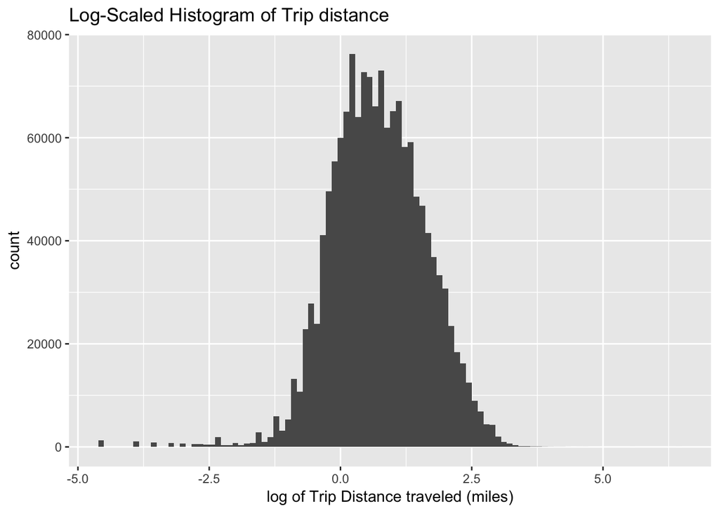

```r
ggplot(data=green_taxi, aes(log(green_taxi$Trip_distance))) + geom_histogram(bins = 100) + xlab("log of Trip Distance traveled (miles)") + ggtitle("Log-Scaled Histogram of Trip distance")
```

Log-scaled histogram is used to make the histogram more readable.

### 2. Report any structure you find and any hypotheses you have about that structure.

Since the histogram is heavily skewed, after some trials to find the plot that better describes the pattern, the trip distance of 20 miles seems to be a better number to zoom the histogram.

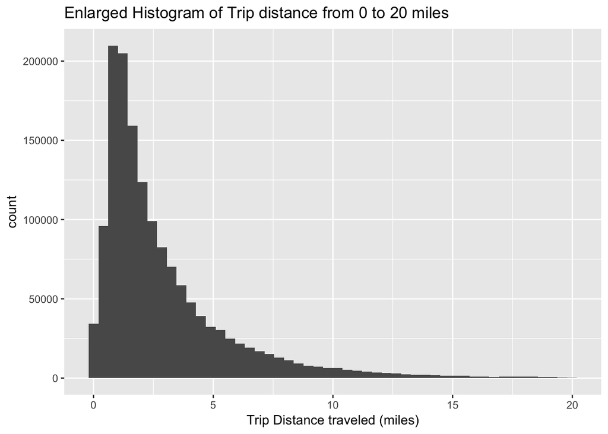

```r
ggplot(data=green_taxi[green_taxi$Trip_distance < 20,], aes(Trip_distance)) + geom_histogram(bins = 50) + xlab("Trip Distance traveled (miles)") + ggtitle("Enlarged Histogram of Trip distance from 0 to 20 miles")
```

**Hypotheses** - We can infer from the histogram that people in NYC prefer to take green taxi for shorter trips within 5 miles rather than traveling to other cities or traveling for a long distance. There are very less trips which was taken for longer distance, it may be the tourist who might have toured around the city.

## Question 3

### 1. Report mean and median trip distance grouped by hour of day.

```r
str(green_taxi)
```

```
## 'data.frame':    1494926 obs. of  21 variables:
##  $ VendorID             : int  2 2 2 2 2 2 2 2 2 2 ...
##  $ lpep_pickup_datetime : chr  "2015-09-01 00:02:34" "2015-09-01 00:04:20" "2015-09-01 00:01:50" "2015-09-01 00:02:36" ...
##  $ Lpep_dropoff_datetime: chr  "2015-09-01 00:02:38" "2015-09-01 00:04:24" "2015-09-01 00:04:24" "2015-09-01 00:06:42" ...
##  $ Store_and_fwd_flag   : chr  "N" "N" "N" "N" ...
##  $ RateCodeID           : int  5 5 1 1 1 1 1 1 1 1 ...
##  $ Pickup_longitude     : num  -74 -74 -73.9 -73.9 -74 ...
##  $ Pickup_latitude      : num  40.7 40.9 40.8 40.8 40.7 ...
##  $ Dropoff_longitude    : num  -74 -74 -73.9 -73.9 -73.9 ...
##  $ Dropoff_latitude     : num  40.7 40.9 40.8 40.8 40.7 ...
##  $ Passenger_count      : int  1 1 1 1 1 1 1 1 1 1 ...
##  $ Trip_distance        : num  0 0 0.59 0.74 0.61 1.07 1.43 0.9 1.33 0.84 ...
##  $ Fare_amount          : num  7.8 45 4 5 5 5.5 6.5 5 6 5.5 ...
##  $ Extra                : num  0 0 0.5 0.5 0.5 0.5 0.5 0.5 0.5 0.5 ...
##  $ MTA_tax              : num  0 0 0.5 0.5 0.5 0.5 0.5 0.5 0.5 0.5 ...
##  $ Tip_amount           : num  1.95 0 0.5 0 0 1.36 0 0 1.46 0 ...
##  $ Tolls_amount         : num  0 0 0 0 0 0 0 0 0 0 ...
##  $ Ehail_fee            : logi  NA NA NA NA NA NA ...
##  $ improvement_surcharge: num  0 0 0.3 0.3 0.3 0.3 0.3 0.3 0.3 0.3 ...
##  $ Total_amount         : num  9.75 45 5.8 6.3 6.3 8.16 7.8 6.3 8.76 6.8 ...
##  $ Payment_type         : int  1 1 1 2 2 1 1 2 1 2 ...
##  $ Trip_type            : int  2 2 1 1 1 1 1 1 1 1 ...
```

```r
#Convert pickup date
green_taxi$lpep_pickup_datetime <- as.POSIXlt(green_taxi$lpep_pickup_datetime, format='%Y-%m-%d %H:%M:%S')

#Convert dropoff date
green_taxi$Lpep_dropoff_datetime <- as.POSIXlt(green_taxi$Lpep_dropoff_datetime, format='%Y-%m-%d %H:%M:%S')

#Create a new column for pickup hour
green_taxi$Pickup_Hour <- hour(green_taxi$lpep_pickup_datetime)
green_taxi$Pickup_Hour <- as.factor(green_taxi$Pickup_Hour) #Convert to factor

#Mean and Median of trip distance in tabular form
grouped_distance <- green_taxi[,c('Pickup_Hour', 'Trip_distance')] %>%  group_by(Pickup_Hour) %>% summarise(mean_distance = mean(Trip_distance), median_distance = median(Trip_distance))
kable(grouped_distance)
```

| Pickup_Hour | mean_distance | median_distance |
| --- | --- | --- |
| 0 | 3.115276 | 2.20 |
| 1 | 3.017347 | 2.12 |
| 2 | 3.046176 | 2.14 |
| 3 | 3.212945 | 2.20 |
| 4 | 3.526555 | 2.36 |
| 5 | 4.133474 | 2.90 |
| 6 | 4.055149 | 2.84 |
| 7 | 3.284394 | 2.17 |
| 8 | 3.048450 | 1.98 |
| 9 | 2.999105 | 1.96 |
| 10 | 2.944482 | 1.92 |
| 11 | 2.912015 | 1.88 |
| 12 | 2.903065 | 1.89 |
| 13 | 2.878294 | 1.84 |
| 14 | 2.864304 | 1.83 |
| 15 | 2.857040 | 1.81 |
| 16 | 2.779852 | 1.80 |
| 17 | 2.679114 | 1.78 |
| 18 | 2.653222 | 1.80 |
| 19 | 2.715597 | 1.85 |
| 20 | 2.777052 | 1.90 |
| 21 | 2.999189 | 2.03 |
| 22 | 3.185393 | 2.20 |
| 23 | 3.191538 | 2.22 |

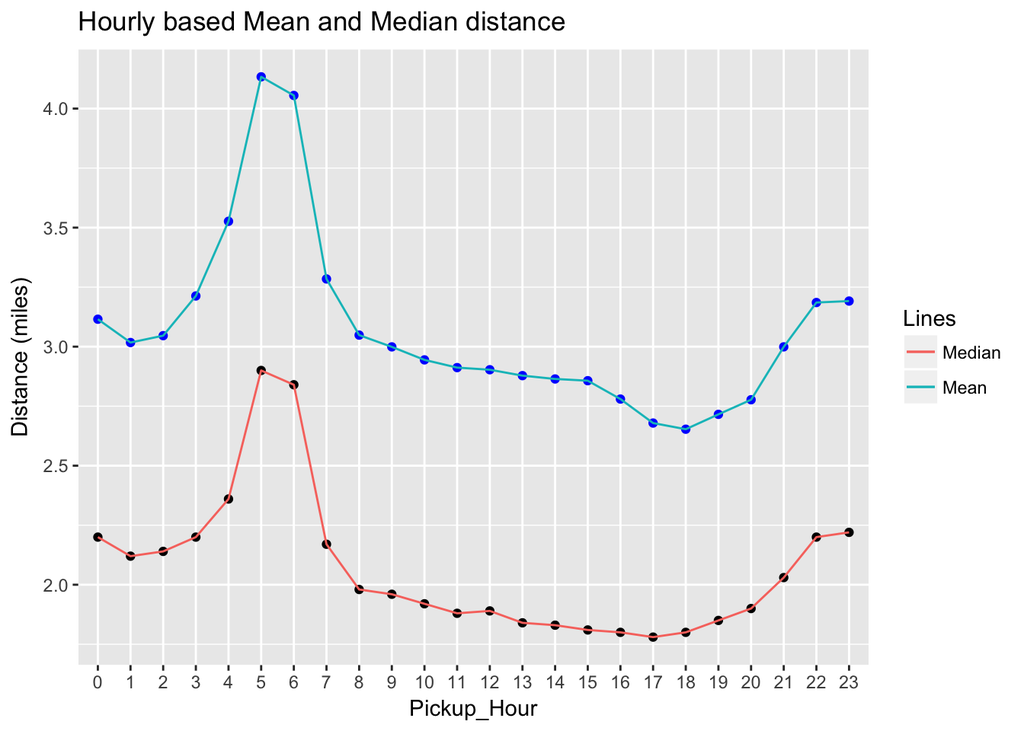

```r
#Plotting mean and median for visual interpretation
gg <- ggplot(grouped_distance, aes(x = Pickup_Hour, group = 1)) + geom_point(aes(y = mean_distance), color = 'Blue') + geom_line(aes(y = mean_distance,color = 'Blue')) + geom_point(aes(y = median_distance), color = 'black') + geom_line(aes(y = median_distance,color = 'black')) + scale_color_discrete(name = "Lines", labels = c("Median", "Mean")) + ggtitle("Hourly based Mean and Median distance") + ylab("Distance (miles)")
gg
```

The mean trip distance is always higher the median trip distance. Also the taxis are traveled more distance during early mornings and it gradually decreases until late evening. There is a slight increase in the travel distance after 8PM until midnight. I suspect that people who are traveling for a longer distance are using the taxi during early morning and late evening.

### 2. We’d like to get a rough sense of identifying trips that originate or terminate at one of the NYC area airports. Can you provide a count of how many transactions fit this criteria, the average fare, and any other interesting characteristics of these trips.

There are 3 airports in New York City.

1. JFK (John F. Kennedy International Airport)
2. LGA (LaGaurdia Airport)
3. EWR (Newark Liberty International Airport)

JFK and EWR has special rates in the RateCodeID. JFK ratecode id is 2 and EWR ID is 3. We can get the latitude and longitude of any address using a ggmap function called “geocode”.

```r
#get latitude and longitude of LaGaurdia airport
laGaurdia <- geocode('Queens, NY 11371')
laGaurdia
```

```
##         lon      lat
## 1 -73.87425 40.77664
```

The pickup or dropoff location will not be exactly at the airport’s latitude and longitude. Hence it is better to round the latitude and longitude to 4 decimal places.

```r
#rounding latitude and longitude to 4 decimal places
laGaurdia$lon = round(laGaurdia$lon, 4)
laGaurdia$lat = round(laGaurdia$lat, 4)

#get latitude and longitude of trips upto 4 decimal places
green_taxi$pickup_long <- as.numeric(substring(green_taxi$Pickup_longitude, 1, 8))
green_taxi$pickup_lat <- as.numeric(substring(green_taxi$Pickup_latitude, 1, 8))
green_taxi$dropoff_long <- as.numeric(substring(green_taxi$Dropoff_longitude, 1, 8))
green_taxi$dropoff_lat <- as.numeric(substring(green_taxi$Dropoff_latitude, 1, 8))

#Retrieve all the records which satisfies the airport condition
airport_taxi = green_taxi[(green_taxi$RateCodeID == 2) | (green_taxi$RateCodeID == 3) | (((green_taxi$pickup_lat) == laGaurdia$lat) & ((green_taxi$pickup_long) == laGaurdia$lon)) | (((green_taxi$dropoff_lat) == laGaurdia$lat) & ((green_taxi$dropoff_long) == laGaurdia$lon)),]
paste0("Total number of pickup and dropoff trips to and from the airport: ", nrow(airport_taxi))
```

```
## [1] "Total number of pickup and dropoff trips to and from the airport: 5552"
```

```r
#print average fare, tip, toll and total amount
avg_amount <- tribble(~Fare_Amount, ~Tip_Amount, ~Toll_Amount, ~Total_Amount,
        paste0("$",round(mean(airport_taxi$Fare_amount),3)), paste0("$",round(mean(airport_taxi$Tip_amount),3)),
        paste0("$",round(mean(airport_taxi$Tolls_amount),3)), paste0("$",round(mean(airport_taxi$Total_amount),3)))
kable(avg_amount)
```

| Fare_Amount | Tip_Amount | Toll_Amount | Total_Amount |
| --- | --- | --- | --- |
| $48.977 | $4.354 | $3.163 | $57.208 |

```r
#Percentage of trips happened for JFK airport
JFK_percent = sum(airport_taxi$RateCodeID == 2)*100/nrow(airport_taxi)
JFK_percent
```

```
## [1] 79.88112
```

```r
#percentage of airport trips compared to non airport trips
airport_percent = nrow(airport_taxi)/(nrow(green_taxi)-nrow(airport_taxi))
airport_percent
```

```
## [1] 0.003727741
```

There are 5552 trips to the airport. LaGaurdia airport has no pickup or dropoff records from the data. Maybe there is no route access for Green taxi to LaGaurdia airport.

The average Fare for the airport is $48.97.

**Other interesting factors:**

1. There are negative fares recorded and all the negative fares use VendorID = 2 which is VeriFone.Inc.
2. Around 79% of the total trips to airports is to JFK airport. Probably JFK airport is more busy than Newark airport.
3. However, it is only 0.3% trips are for airport when compared to non airport trips. Hence whenever a trip is for airport, it is 79% chance that the airport is JFK. However, very less people prefer traveling to airports using Green taxi.

## Question 4

### 1. Build a derived variable for tip as a percentage of the total fare.

Inorder to calculate the percentage for tips, we need to filter out the data which has the total amount less than and equal to 0 to avoid floating point error.

```r
tip_calculate <- green_taxi[green_taxi$Total_amount > 0,]
tip_calculate$Tip_percent <- (tip_calculate$Tip_amount/tip_calculate$Total_amount)*100
summary(tip_calculate$Tip_percent)
```

```
##    Min. 1st Qu.  Median    Mean 3rd Qu.    Max.
##   0.000   0.000   0.000   6.664  16.670 100.000
```

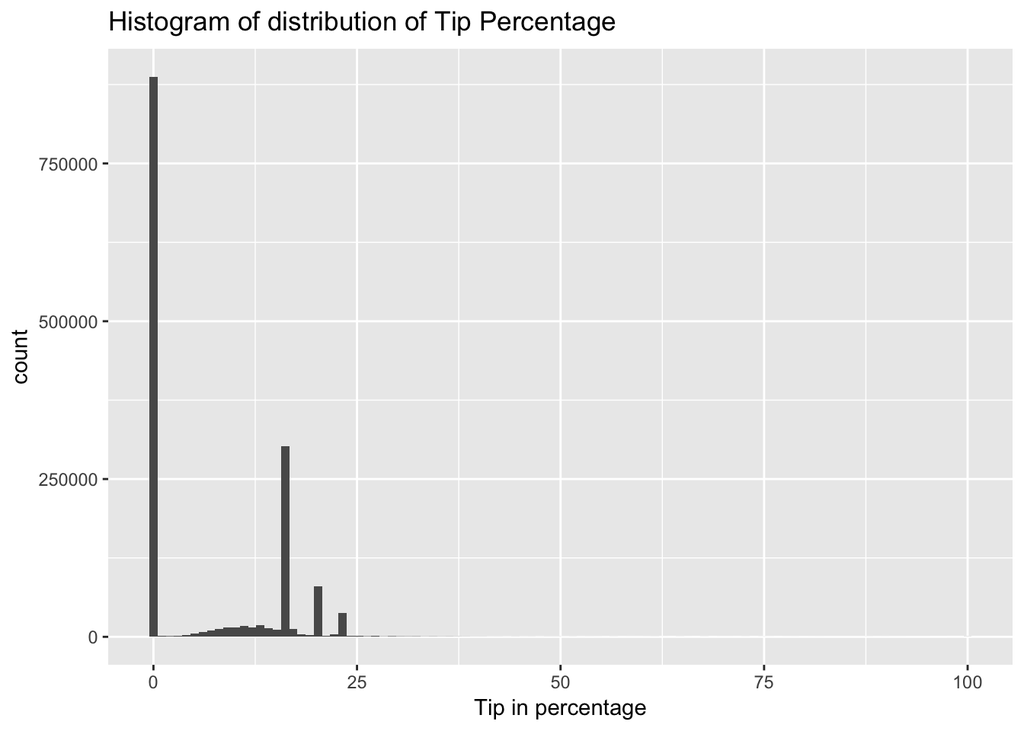

```r
ggplot(data=tip_calculate, aes(tip_calculate$Tip_percent)) + geom_histogram(bins = 100) +
  xlab("Tip in percentage") + ggtitle("Histogram of distribution of Tip Percentage")
```

The average tip percentage for the trips is $6.66. Over 60% of the commuters have not given any tip. However, there are over 250,000 commuters who have given 15-16% tip. There are few very generous people out there in NYC. :)

### 2. Build a predictive model for tip as a percentage of the total fare. Use as much of the data as you like (or all of it). We will validate a sample.

Let us build a regression model to predict tip as a percentage. The following is the set of steps that will be followed

1. Data Loading
2. Handling missing values
3. Adding Tip percentage column/variable
4. Identify Categorical variables, Numeric variables and logical variables
5. Exploratory Data Analysis
6. Stratified sampling to get train and test data.
7. Multiple regression
8. Feature selection using Backward Elimination
9. Model selection - final thoughts

### Data Loading

```r
url = "https://s3.amazonaws.com/nyc-tlc/trip+data/green_tripdata_2015-09.csv"
file_name = "green_tripdata_2015-09.csv"

# Condition to check whether the dataset is present in the local disk
if(!file.exists(file_name)) {
    download.file(url, destfile=file_name, method="curl")
}

# Loading the data
green_taxi <- read.csv("green_tripdata_2015-09.csv", header = TRUE, stringsAsFactors = FALSE)
```

### Handling missing data

There are two columns which has missing values.

**Ehail_fee** - Completely missing

**Trip_type** - 4 missing values

All the 4 trip_type has RateCodeID as “99” which is not an actual rate code provided by TLC. These missing values can be handled in the following way.

1. Remove the entire row which contains a missing value.
2. Impute the missing values with most occuring value in the column which is 1.
3. Impute the missing values using KNN Imputation.

For now we will impute the missing values with the most common occuring value 1.

```r
#Remove the entire column
green_taxi$Ehail_fee <- NULL

#Cited mode function from Stackoverflow https://stackoverflow.com/questions/2547402/is-there-a-built-in-function-for-finding-the-mode
Mode <- function(x) {
  ux <- unique(x)
  ux[which.max(tabulate(match(x, ux)))]
}

green_taxi$Trip_type[is.na(green_taxi$Trip_type)] <- Mode(green_taxi$Trip_type)
```

### Adding Tip percentage column/variable

Tip percentage is calculated by tip amount divided by the total amount.

```r
#filter the data with total amount greater than 0 and calculate tip percent
green_taxi <- green_taxi[green_taxi$Total_amount > 0,]
green_taxi$Tip_percent <- (green_taxi$Tip_amount/green_taxi$Total_amount)*100
```

### Identify Categorical variables, Numeric variables and logical variables

Identifying these variables wil help better understand the data and distribution of each variable.

```r
#Convert pickup and dropoff to datetime
green_taxi$lpep_pickup_datetime <- as.POSIXlt(green_taxi$lpep_pickup_datetime, format='%Y-%m-%d %H:%M:%S')
green_taxi$Lpep_dropoff_datetime <- as.POSIXlt(green_taxi$Lpep_dropoff_datetime, format='%Y-%m-%d %H:%M:%S')

#Convert to categorical variables
green_taxi$Store_and_fwd_flag <- factor(green_taxi$Store_and_fwd_flag, levels = c("N", "Y"), labels = c(0,1))
green_taxi$RateCodeID <- as.factor(green_taxi$RateCodeID)
green_taxi$Passenger_count <- as.factor(green_taxi$Passenger_count)
green_taxi$Payment_type <- as.factor(green_taxi$Payment_type)
green_taxi$Trip_type <- as.factor(green_taxi$Trip_type)

categorical_variables <- names(which(sapply(green_taxi, is.factor)))
categorical_variables
```

```
## [1] "Store_and_fwd_flag" "RateCodeID"         "Passenger_count"
## [4] "Payment_type"       "Trip_type"
```

```r
numeric_variables <- names(which(sapply(green_taxi, is.numeric)))
numeric_variables
```

```
##  [1] "VendorID"              "Pickup_longitude"
##  [3] "Pickup_latitude"       "Dropoff_longitude"
##  [5] "Dropoff_latitude"      "Trip_distance"
##  [7] "Fare_amount"           "Extra"
##  [9] "MTA_tax"               "Tip_amount"
## [11] "Tolls_amount"          "improvement_surcharge"
## [13] "Total_amount"          "Tip_percent"
```

```r
logical_variables <- names(which(sapply(green_taxi, is.logical)))
logical_variables
```

```
## character(0)
```

```r
datetime_variables <- names(which(sapply(green_taxi, is.POSIXlt)))
datetime_variables
```

```
## [1] "lpep_pickup_datetime"  "Lpep_dropoff_datetime"
```

#### To make sure I didn’t miss any variables

```r
#condition to check for the column count to be equal by summing these variables
stopifnot(length(numeric_variables) + length(categorical_variables) + length(logical_variables) + length(datetime_variables) == ncol(green_taxi))
```

### Exploratory Data Analysis

#### Check the Correlation between the attributes

Correlation plot and matrix are used to find the correlation between the variables. This will help find any relationship between the variables.

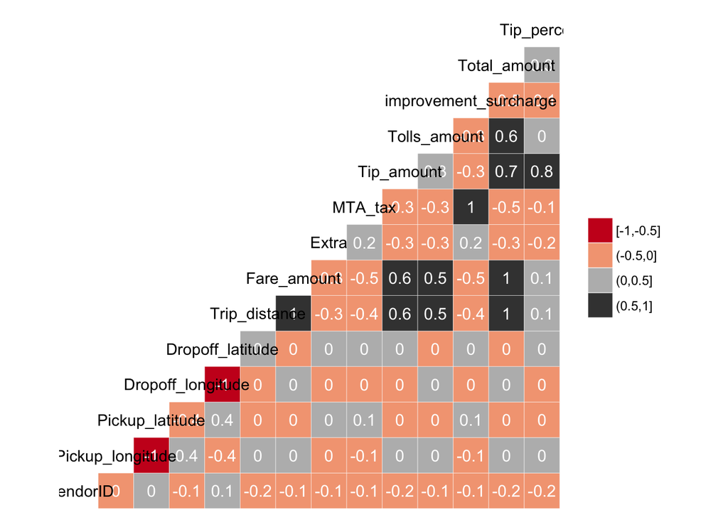

```r
my_function <- function(data, mapping, ...) {
  p <- ggplot(data = data, mapping = mapping) + geom_point() +
    geom_smooth(method = lm, fill = "blue", color = "orange", ...)
  p
}
data_set_relation <- green_taxi[, numeric_variables]

### ggpairs is commented as it is taking a very long time to plot. This plot gives shows the correlation value with the distribution.
#g = ggpairs(data_set_relation, lower = list(continuous = my_function)) + theme(text = element_text(size = 10))
#g

correlation_matrix <- cor(green_taxi[,numeric_variables])
ggcorr(correlation_matrix, nbreaks = 4, palette = "RdGy", label = TRUE, label_size = 4, label_color = "white", hjust = 0.5)
```

Trip distance, Fare amount and Total amount are all perfectly positively correlated which makes sense that as the distance traveled is more, Fare amount is increased which increases Total amount.

### Stratified sampling to split our data into training and test sets

We will split the dataset into train and test data with 80:20 ratio for train and test. The train data is used to build a regression model so that the model can learn any pattern with 80% of the data. Inorder to validate them, we use test data to predict the tip percent by hiding the response variable and comparing the predictions with the actual value using r squared and Root mean square error evaluation metric.

```r
targetVar <- "Tip_percent"
Xvars <- c('VendorID', 'Store_and_fwd_flag', 'RateCodeID', 'Pickup_longitude',
       'Pickup_latitude', 'Dropoff_longitude', 'Dropoff_latitude',
       'Passenger_count', 'Trip_distance', 'Fare_amount', 'Extra', 'MTA_tax',
       'Tip_amount', 'Tolls_amount', 'improvement_surcharge',
       'Total_amount', 'Payment_type', 'Trip_type')
set.seed(3456)
inTrain <- createDataPartition(y = green_taxi[,targetVar], list = FALSE, p = .80)
train <- green_taxi[inTrain,]
test <- green_taxi[-inTrain,]
stopifnot(nrow(train) + nrow(test) == nrow(green_taxi))
```

#### Function to create a model formula

```r
createModelFormula <- function(targetVar, xVars, includeIntercept = TRUE){
  if(includeIntercept){
    modelForm <- as.formula(paste(targetVar, "~", paste(xVars, collapse = '+ ')))
  } else {
    modelForm <- as.formula(paste(targetVar, "~", paste(xVars, collapse = '+ '), -1))
  }
  return(modelForm)
}
set.seed(13)
#Input the independent variable and response variable to get the formula
full_modelForm <- createModelFormula(targetVar, Xvars)
```

### Multiple regression

#### Full model

Let us first implement multiple regression with full model excluding the pickup and dropoff datetime columns. The model is trained using train data and the predictions are made using test data. As an evaluation metric, I have used R square explicitly and root mean squared error.

```r
set.seed(13)
full_model <- lm(full_modelForm , data = train)
summary(full_model)
```

```
##
## Call:
## lm(formula = full_modelForm, data = train)
##
## Residuals:
##     Min      1Q  Median      3Q     Max
## -468.05   -1.08   -0.18    1.89   87.76
##
## Coefficients:
##                        Estimate Std. Error   t value Pr(>|t|)
## (Intercept)           12.224706   0.401664    30.435  < 2e-16 ***
## VendorID              -0.101852   0.009377   -10.862  < 2e-16 ***
## Store_and_fwd_flag1   -0.017926   0.050018    -0.358  0.72005
## RateCodeID2            1.724394   0.072926    23.646  < 2e-16 ***
## RateCodeID3           -2.189244   0.270932    -8.080 6.46e-16 ***
## RateCodeID4            1.412182   0.153167     9.220  < 2e-16 ***
## RateCodeID5           -0.938334   0.142815    -6.570 5.03e-11 ***
## RateCodeID6           -1.275780   0.817490    -1.561  0.11862
## RateCodeID99          -7.373926   2.392066    -3.083  0.00205 **
## Pickup_longitude      -1.360108   0.055410   -24.546  < 2e-16 ***
## Pickup_latitude       -2.440926   0.100468   -24.296  < 2e-16 ***
## Dropoff_longitude     -1.532028   0.054654   -28.031  < 2e-16 ***
## Dropoff_latitude      -2.785257   0.099147   -28.092  < 2e-16 ***
## Passenger_count1       0.536735   0.281948     1.904  0.05695 .
## Passenger_count2       0.615623   0.282192     2.182  0.02914 *
## Passenger_count3       0.633231   0.282957     2.238  0.02523 *
## Passenger_count4       0.688948   0.285611     2.412  0.01586 *
## Passenger_count5       0.611143   0.282596     2.163  0.03057 *
## Passenger_count6       0.632898   0.283626     2.231  0.02565 *
## Passenger_count7       1.496550   1.167700     1.282  0.19998
## Passenger_count8      -3.882339   0.864243    -4.492 7.05e-06 ***
## Passenger_count9       3.616360   1.263772     2.862  0.00422 **
## Trip_distance         -0.089586   0.002396   -37.398  < 2e-16 ***
## Fare_amount           -0.439314   0.140770    -3.121  0.00180 **
## Extra                 -0.393904   0.141163    -2.790  0.00526 **
## MTA_tax               -1.988925   0.487397    -4.081 4.49e-05 ***
## Tip_amount             1.551672   0.140776    11.022  < 2e-16 ***
## Tolls_amount          -0.541699   0.140839    -3.846  0.00012 ***
## improvement_surcharge -2.982526   0.457864    -6.514 7.32e-11 ***
## Total_amount           0.287217   0.140766     2.040  0.04131 *
## Payment_type2         -9.751321   0.009035 -1079.288  < 2e-16 ***
## Payment_type3         -9.836437   0.073641  -133.573  < 2e-16 ***
## Payment_type4         -9.772063   0.078230  -124.914  < 2e-16 ***
## Payment_type5         -9.771891   0.532154   -18.363  < 2e-16 ***
## Trip_type2            -1.602936   0.222280    -7.211 5.54e-13 ***
## ---
## Signif. codes:  0 '***' 0.001 '**' 0.01 '*' 0.05 '.' 0.1 ' ' 1
##
## Residual standard error: 4.086 on 1190636 degrees of freedom
## Multiple R-squared:  0.7883, Adjusted R-squared:  0.7883
## F-statistic: 1.304e+05 on 34 and 1190636 DF,  p-value: < 2.2e-16
```

```r
mpg_hat <- paste0(targetVar,"_hat")
test[,mpg_hat] = predict(full_model,test)
SST <- sum((test[,targetVar] - mean(test[,targetVar]))^2)
SSR <- sum((mean(test[,targetVar]) - test[,mpg_hat])^2)
R_square<-SSR/SST
R_square
```

```
## [1] 0.7942254
```

```r
#Root mean square error
rmse_full_model <- mean((test$Tip_percent - test[,mpg_hat])^2)
print(rmse_full_model)
```

```
## [1] 16.74705
```

From the summary, the estimated coefficients of the variables are reasonable, this shows that the model did not overfit.

#### Feature selection using Backward Elimination

Backward elimination has an advantage over Forward selection as Forward selection is a greedy approach. It is possible for the variables to have predictive power even though some of the subset of the variables do not explain and Forward selection will not catch this. Hence, Backward elimination is useful as it starts with all the variables and any correlation and joint prediction can be found easily.

```r
#Backward elimiation with detailed output
ols_step_backward(full_model, details = TRUE)
```

```
## We are eliminating variables based on p value...
```

```
## Backward Elimination: Step 1
##
##  Variable Store_and_fwd_flag Removed
##
##                         Model Summary
## --------------------------------------------------------------
## R                       0.888       RMSE                4.086
## R-Squared               0.788       Coef. Var          61.317
## Adj. R-Squared          0.788       MSE                16.699
## Pred R-Squared          0.788       MAE                 2.459
## --------------------------------------------------------------
##  RMSE: Root Mean Square Error
##  MSE: Mean Square Error
##  MAE: Mean Absolute Error
##
##                                       ANOVA
## ---------------------------------------------------------------------------------
##                     Sum of
##                    Squares             DF    Mean Square        F           Sig.
## ---------------------------------------------------------------------------------
## Regression    74048468.508             33    2243892.985    134370.512    0.0000
## Residual      19882800.031        1190637         16.699
## Total         93931268.539        1190670
## ---------------------------------------------------------------------------------
##
##                                          Parameter Estimates
## ------------------------------------------------------------------------------------------------------
##                 model      Beta    Std. Error    Std. Beta        t         Sig       lower     upper
## ------------------------------------------------------------------------------------------------------
##           (Intercept)    12.221         0.402                    30.437    0.000     11.434    13.008
##              VendorID    -0.101         0.009       -0.005      -10.917    0.000     -0.120    -0.083
##           RateCodeID2     1.724         0.073        0.010       23.645    0.000      1.581     1.867
##           RateCodeID3    -2.189         0.271       -0.007       -8.079    0.000     -2.720    -1.658
##           RateCodeID4     1.412         0.153        0.004        9.220    0.000      1.112     1.712
##           RateCodeID5    -0.938         0.143       -0.015       -6.570    0.000     -1.218    -0.658
##           RateCodeID6    -1.276         0.817       -0.001       -1.561    0.119     -2.878     0.326
##          RateCodeID99    -7.388         2.392       -0.001       -3.089    0.002    -12.075    -2.700
##      Pickup_longitude    -1.360         0.055       -0.406      -24.545    0.000     -1.469    -1.251
##       Pickup_latitude    -2.441         0.100       -0.402      -24.295    0.000     -2.638    -2.244
##     Dropoff_longitude    -1.532         0.055       -0.439      -28.032    0.000     -1.639    -1.425
```

[output cut: 9 more lines]

```
##      Passenger_count9     3.616         1.264        0.001        2.862    0.004      1.139     6.093
##         Trip_distance    -0.090         0.002       -0.031      -37.397    0.000     -0.094    -0.085
##           Fare_amount    -0.439         0.141       -0.493       -3.121    0.002     -0.715    -0.163
##                 Extra    -0.394         0.141       -0.016       -2.790    0.005     -0.671    -0.117
##               MTA_tax    -1.988         0.487       -0.016       -4.080    0.000     -2.944    -1.033
##            Tip_amount     1.552         0.141        0.425       11.022    0.000      1.276     1.828
##          Tolls_amount    -0.542         0.141       -0.054       -3.846    0.000     -0.818    -0.266
## improvement_surcharge    -2.981         0.458       -0.014       -6.511    0.000     -3.878    -2.084
##          Total_amount     0.287         0.141        0.370        2.040    0.041      0.011     0.563
##         Payment_type2    -9.751         0.009       -0.548    -1079.332    0.000     -9.769    -9.734
##         Payment_type3    -9.837         0.074       -0.057     -133.586    0.000     -9.981    -9.692
##         Payment_type4    -9.772         0.078       -0.053     -124.921    0.000     -9.926    -9.619
##         Payment_type5    -9.773         0.532       -0.008      -18.365    0.000    -10.816    -8.730
##            Trip_type2    -1.602         0.222       -0.025       -7.208    0.000     -2.038    -1.167
## ------------------------------------------------------------------------------------------------------
```

```
## No more variables satisfy the condition of prem: 0.3
```

```
## Backward Elimination Method
##
## Candidate Terms:
##
## 1 . VendorID
## 2 . Store_and_fwd_flag
## 3 . RateCodeID
## 4 . Pickup_longitude
## 5 . Pickup_latitude
## 6 . Dropoff_longitude
## 7 . Dropoff_latitude
## 8 . Passenger_count
## 9 . Trip_distance
## 10 . Fare_amount
## 11 . Extra
## 12 . MTA_tax
## 13 . Tip_amount
## 14 . Tolls_amount
## 15 . improvement_surcharge
## 16 . Total_amount
## 17 . Payment_type
## 18 . Trip_type
##
## --------------------------------------------------------------------------------------
##                                  Elimination Summary
## --------------------------------------------------------------------------------------
##         Variable                            Adj.
## Step         Removed          R-Square    R-Square     C(p)         AIC          RMSE
## --------------------------------------------------------------------------------------
##    1    Store_and_fwd_flag      0.7883      0.7883    1.1284    6731189.2651    4.0865
## --------------------------------------------------------------------------------------
```

Backward elimination using p value as a criteria removes just one column “Store and fwdflag”. I also tried with AIC value which gave me the same output. Hence we will train a new model with no “Store and few flag” column.

```r
Xvars <- c('VendorID', 'RateCodeID', 'Pickup_longitude',
       'Pickup_latitude', 'Dropoff_longitude', 'Dropoff_latitude',
       'Passenger_count', 'Trip_distance', 'Fare_amount', 'Extra', 'MTA_tax',
       'Tip_amount', 'Tolls_amount', 'improvement_surcharge',
       'Total_amount', 'Payment_type', 'Trip_type')

select_modelForm <- createModelFormula(targetVar = targetVar, xVars = Xvars)

set.seed(144)
selected_model <- lm(select_modelForm , data = train)
summary(selected_model)
```

```
##
## Call:
## lm(formula = select_modelForm, data = train)
##
## Residuals:
##     Min      1Q  Median      3Q     Max
## -468.05   -1.08   -0.18    1.89   87.76
##
## Coefficients:
##                        Estimate Std. Error   t value Pr(>|t|)
## (Intercept)           12.220692   0.401508    30.437  < 2e-16 ***
## VendorID              -0.101388   0.009287   -10.917  < 2e-16 ***
## RateCodeID2            1.724352   0.072926    23.645  < 2e-16 ***
## RateCodeID3           -2.188941   0.270931    -8.079 6.52e-16 ***
## RateCodeID4            1.412272   0.153167     9.220  < 2e-16 ***
## RateCodeID5           -0.938345   0.142815    -6.570 5.02e-11 ***
## RateCodeID6           -1.276042   0.817489    -1.561  0.11854
## RateCodeID99          -7.387661   2.391758    -3.089  0.00201 **
## Pickup_longitude      -1.360059   0.055410   -24.545  < 2e-16 ***
## Pickup_latitude       -2.440851   0.100468   -24.295  < 2e-16 ***
## Dropoff_longitude     -1.532069   0.054654   -28.032  < 2e-16 ***
## Dropoff_latitude      -2.785261   0.099147   -28.092  < 2e-16 ***
## Passenger_count1       0.536743   0.281948     1.904  0.05695 .
## Passenger_count2       0.615617   0.282192     2.182  0.02914 *
## Passenger_count3       0.633226   0.282957     2.238  0.02523 *
## Passenger_count4       0.688953   0.285610     2.412  0.01586 *
## Passenger_count5       0.611151   0.282596     2.163  0.03057 *
## Passenger_count6       0.632907   0.283626     2.231  0.02565 *
## Passenger_count7       1.496483   1.167699     1.282  0.20000
## Passenger_count8      -3.882308   0.864243    -4.492 7.05e-06 ***
## Passenger_count9       3.616349   1.263772     2.862  0.00422 **
## Trip_distance         -0.089586   0.002396   -37.397  < 2e-16 ***
## Fare_amount           -0.439319   0.140770    -3.121  0.00180 **
## Extra                 -0.393870   0.141163    -2.790  0.00527 **
## MTA_tax               -1.988338   0.487394    -4.080 4.51e-05 ***
## Tip_amount             1.551669   0.140776    11.022  < 2e-16 ***
## Tolls_amount          -0.541705   0.140839    -3.846  0.00012 ***
## improvement_surcharge -2.980975   0.457843    -6.511 7.47e-11 ***
## Total_amount           0.287221   0.140766     2.040  0.04131 *
## Payment_type2         -9.751349   0.009035 -1079.332  < 2e-16 ***
## Payment_type3         -9.836739   0.073636  -133.586  < 2e-16 ***
## Payment_type4         -9.772272   0.078228  -124.921  < 2e-16 ***
## Payment_type5         -9.772901   0.532147   -18.365  < 2e-16 ***
## Trip_type2            -1.602149   0.222269    -7.208 5.68e-13 ***
## ---
## Signif. codes:  0 '***' 0.001 '**' 0.01 '*' 0.05 '.' 0.1 ' ' 1
##
## Residual standard error: 4.086 on 1190637 degrees of freedom
## Multiple R-squared:  0.7883, Adjusted R-squared:  0.7883
## F-statistic: 1.344e+05 on 33 and 1190637 DF,  p-value: < 2.2e-16
```

```r
mpg_hat <- paste0(targetVar,"_hat")
test[,mpg_hat] = predict(selected_model,test)
SST <- sum((test[,targetVar] - mean(test[,targetVar]))^2)
SSR <- sum((mean(test[,targetVar]) - test[,mpg_hat])^2)
R_square<-SSR/SST
R_square
```

```
## [1] 0.7942255
```

```r
#root mean square error
rmse_selected_model <- mean((test$Tip_percent - test[,mpg_hat])^2)
print(rmse_selected_model)
```

```
## [1] 16.74708
```

```r
#The ols_best_subset function is used to get the best model. I commented it as it takes more time.
#ols_best_subset(selected_model)
```

There are no much difference in the R square value and the RMSE value is just the same.

I tried implementing Random forest regressor but it takes a long time to run with just 20 trees. Due to lack of processing capacity in my laptop, I could not implement random forest regressor.

### Model selection - Final Thoughts

The full model of multiple regression and selected model from backward elimination is almost equal. As a final model, I would prefer the selected model as it gives the same prediction with fewer features which makes the model less complicated.

## Question 5 - Option A: Distributions

### 1. Build a derived variable representing the average speed over the course of a trip.

We know that speed = distance/time. We can derive the average speed over the course of the trip by getting the trip distance and calculating time taken from pickup and dropoff columns.

```r
#filter data with distance greater than 0.
trip_data = green_taxi[green_taxi$Trip_distance > 0,]

#Extract time in seconds
trip_data$Time = as.numeric(difftime(trip_data$Lpep_dropoff_datetime, trip_data$lpep_pickup_datetime, units = "secs"))

#Create a new variable for average speed
trip_data$Avg_speed = round((trip_data$Trip_distance)/round(((trip_data$Time)/3600),2),2)

#remove records with average speed equals infinity
trip_data = trip_data[trip_data$Avg_speed != Inf,] #Remove Inf records

summary(trip_data$Avg_speed) #overview of the column
```

```
##    Min. 1st Qu.  Median    Mean 3rd Qu.    Max.
##    0.00    9.42   11.82   13.30   15.10 7670.00
```

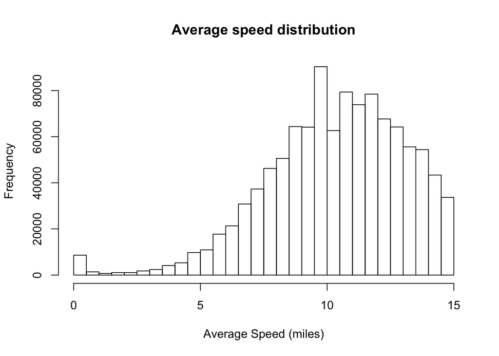

```r
hist(trip_data$Avg_speed[trip_data$Avg_speed < 15], main = "Average speed distribution", xlab = "Average Speed (miles)")
```

### 2. Can you perform a test to determine if the average trip speeds are materially the same in all weeks of September? If you decide they are not the same, can you form a hypothesis regarding why they differ?

Let us define the hypothesis as below,

- Null hypothesis H0 : The means of the speeds for all the weeks are same.
- Alternate Hypothesis H1 : Atleast one of the mean speed is not equal.

```r
trip_data$week = as.numeric(strftime(trip_data$lpep_pickup_datetime, "%W"))
avg_summary = trip_data[,c('week', 'Avg_speed')] %>%  group_by(week_number = week) %>% summarise(Average_Speed = mean(Avg_speed))
kable(avg_summary)
```

| week_number | Average_Speed |
| --- | --- |
| 35 | 13.87414 |
| 36 | 13.06888 |
| 37 | 12.99208 |
| 38 | 13.56968 |
| 39 | 12.81951 |

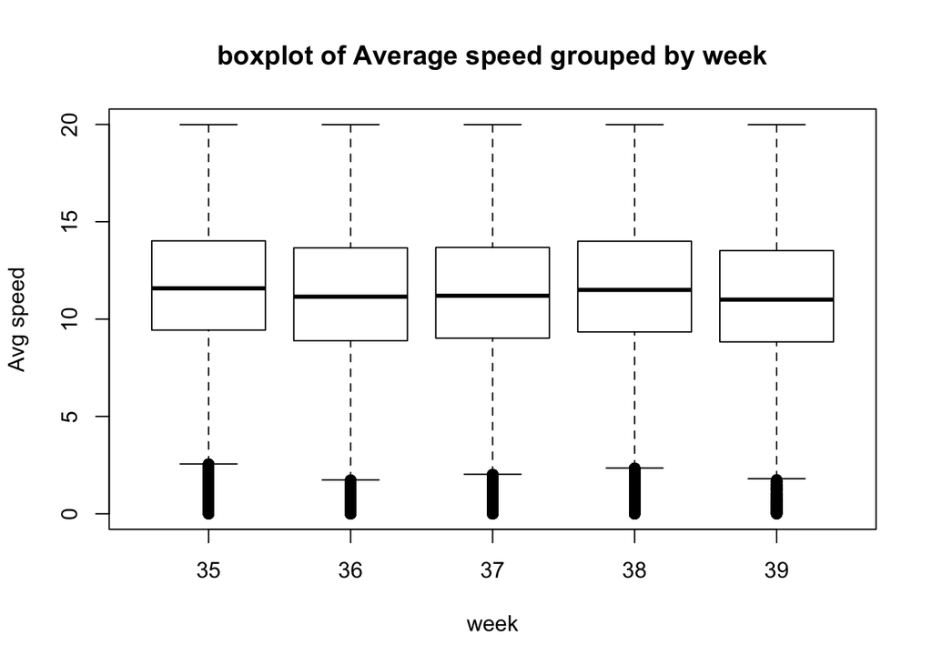

```r
boxplot(Avg_speed ~ week, main = "boxplot of Average speed grouped by week", xlab='week',ylab='Avg speed', data = trip_data[trip_data$Avg_speed < 20,])
```

```r
anova1 = aov(Avg_speed ~ week, data = trip_data) #Fitting ANOVA
summary(anova1) #Prints the summary and ANOVA table
```

```
##                  Df    Sum Sq Mean Sq F value Pr(>F)
## week              1     36057   36057   86.31 <2e-16 ***
## Residuals   1464585 611827514     418
## ---
## Signif. codes:  0 '***' 0.001 '**' 0.01 '*' 0.05 '.' 0.1 ' ' 1
```

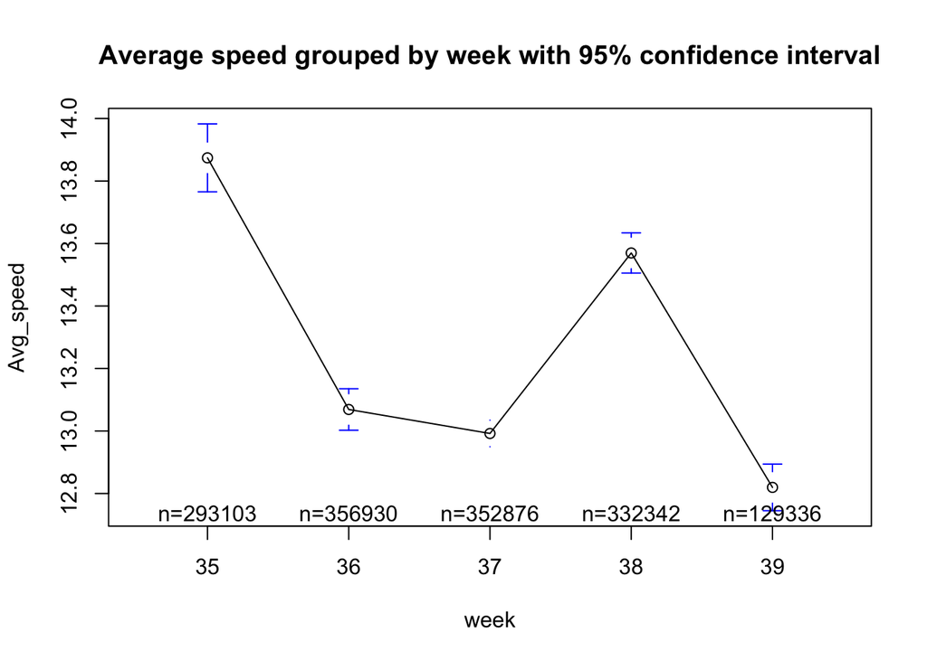

```r
#function to plot the means with 95% confidence interval
plotmeans(Avg_speed ~ week, data = trip_data, main = "Average speed grouped by week with 95% confidence interval")
```

From the summary of the anova, the p value is less than 0.001 which is highly significant. Hence we reject the null hypothesis and conclude that atleast one of the mean speed for the weeks are not equal.

### Can you build up a hypothesis of average trip speed as a function of time of day?

Let us define the hypothesis as below,

- Null hypothesis H0 : The means of the speeds for the hours is the same.
- Alternate Hypothesis H1 : Atleast one of the mean speed is not equal.

```r
trip_data$hour = as.numeric(strftime(trip_data$lpep_pickup_datetime, "%H"))

time_summary = trip_data[,c('hour', 'Avg_speed')] %>%  group_by(Hours = hour) %>% summarise(Average_Speed = mean(Avg_speed))
kable(time_summary)
```

| Hours | Average_Speed |
| --- | --- |
| 0 | 15.00753 |
| 1 | 15.45449 |
| 2 | 16.06248 |
| 3 | 16.32299 |
| 4 | 16.83932 |
| 5 | 18.38361 |
| 6 | 17.63817 |
| 7 | 13.77610 |
| 8 | 12.58586 |
| 9 | 12.81322 |
| 10 | 12.88669 |
| 11 | 12.63647 |
| 12 | 12.80981 |
| 13 | 12.48570 |
| 14 | 11.91989 |
| 15 | 11.62423 |
| 16 | 11.47578 |
| 17 | 11.23777 |
| 18 | 11.76570 |
| 19 | 12.32697 |
| 20 | 13.03493 |
| 21 | 13.95594 |
| 22 | 14.57353 |
| 23 | 14.82908 |

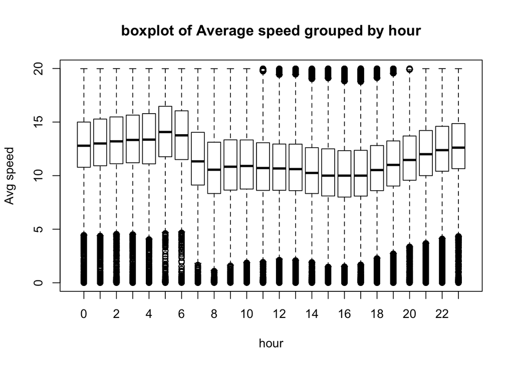

```r
boxplot(Avg_speed ~ hour,main = "boxplot of Average speed grouped by hour", xlab='hour',ylab='Avg speed', data = trip_data[trip_data$Avg_speed < 20,])
```

```r
time_anova = aov(Avg_speed ~ hour, data = trip_data) #Fitting ANOVA
summary(time_anova) #Prints the summary and ANOVA table
```

```
##                  Df    Sum Sq Mean Sq F value Pr(>F)
## hour              1    738613  738613    1770 <2e-16 ***
## Residuals   1464585 611124958     417
## ---
## Signif. codes:  0 '***' 0.001 '**' 0.01 '*' 0.05 '.' 0.1 ' ' 1
```

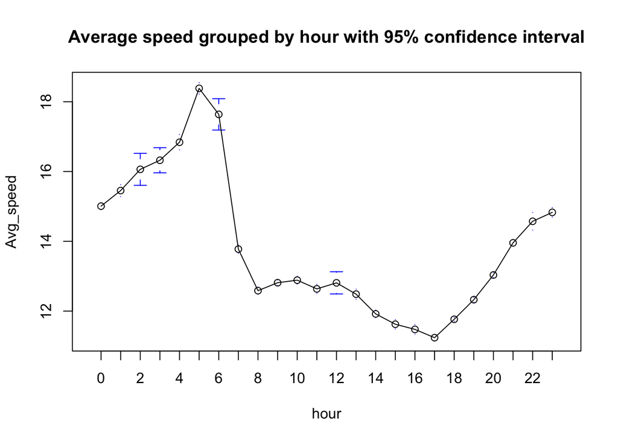

```r
plotmeans(Avg_speed ~ hour, data = trip_data, main = "Average speed grouped by hour with 95% confidence interval", n.label = FALSE)
```

Similar to previous anova resut, from the summary of the anova, the p value is less than 0.001 which is highly significant. Hence we reject the null hypothesis and conclude that atleast one of the mean speed grouped by hours are not equal.

## Future work

I would breakdown the pickup/dropoff datetime variable to day, hours and minutes to build a random forest regressor model which I believe will give better results as most of the columns are categorical and it is much easier for the random forest algorithm to build trees.

Also, I would want to make a route map graph and check for the busiest route or locality using ggmap.